# examples_0529

To find $c_{2,1}$, you use row 2 from matrix $A$ and column 1 from matrix $B$.

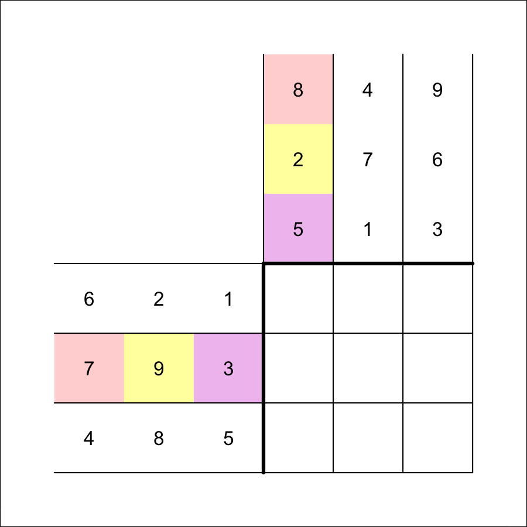

You multiply corresponding elements and sum those products.

$$c_{2,1}~=~( 7 \cdot 8 )+( 9 \cdot 2
)+( 3 \cdot 5 )$$

$$c_{2,1}~=~56+18+15$$

$$c_{2,1}~=~89$$

If you repeat this process for all 9 elements in $C$, you get:

$$\begin{bmatrix}
6 & 2 & 1\\
7 & 9 & 3\\
4 & 8 & 5
\end{bmatrix} \cdot \begin{bmatrix}
8 & 4 & 9\\
2 & 7 & 6\\
5 & 1 & 3
\end{bmatrix} ~=~ \begin{bmatrix}
57 & 39 & 69\\
89 & 94 & 126\\
73 & 77 & 99
\end{bmatrix}$$

Let matrices $A$ and $B$ be defined below.

$$A = \begin{bmatrix}
8 & 4 & 6\\
1 & 9 & 7\\
5 & 3 & 2
\end{bmatrix}$$
$$B = \begin{bmatrix}
9 & 7 & 4\\
8 & 6 & 2\\
1 & 3 & 5
\end{bmatrix}$$

A third matrix, $C$, is equal to the [product](https://en.wikipedia.org/wiki/Matrix_multiplication) $AB$. A student set up a diagram to help find the product:

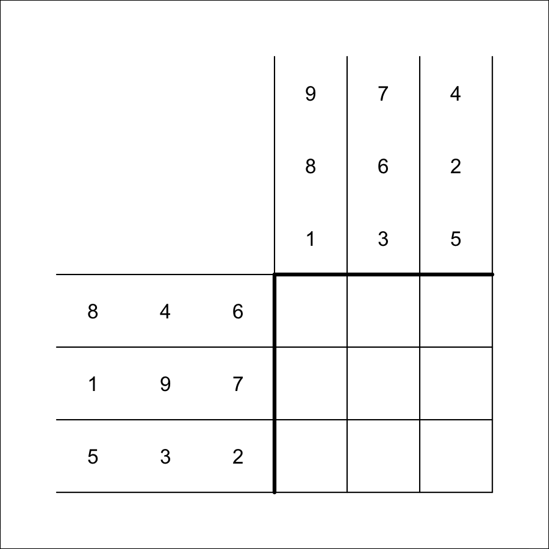

What is $c_{1,3}$?

To find $c_{1,3}$, you use row 1 from matrix $A$ and column 3 from matrix $B$.

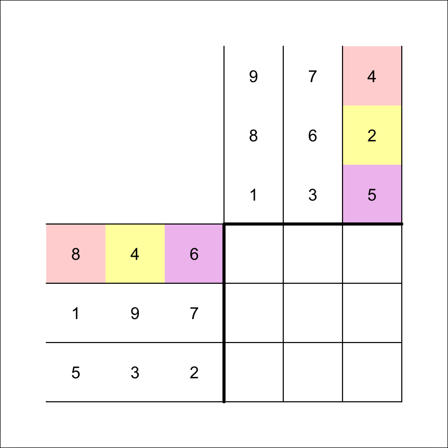

You multiply corresponding elements and sum those products.

$$c_{1,3}~=~( 8 \cdot 4 )+( 4 \cdot 2
)+( 6 \cdot 5 )$$

$$c_{1,3}~=~32+8+30$$

$$c_{1,3}~=~70$$

If you repeat this process for all 9 elements in $C$, you get:

$$\begin{bmatrix}
8 & 4 & 6\\
1 & 9 & 7\\
5 & 3 & 2
\end{bmatrix} \cdot \begin{bmatrix}
9 & 7 & 4\\
8 & 6 & 2\\
1 & 3 & 5
\end{bmatrix} ~=~ \begin{bmatrix}
110 & 98 & 70\\
88 & 82 & 57\\
71 & 59 & 36
\end{bmatrix}$$

Let matrices $A$ and $B$ be defined below.

$$A = \begin{bmatrix}
9 & 3 & 5\\
2 & 6 & 7\\
8 & 1 & 4
\end{bmatrix}$$
$$B = \begin{bmatrix}
4 & 1 & 7\\
6 & 5 & 8\\
3 & 2 & 9
\end{bmatrix}$$

A third matrix, $C$, is equal to the [product](https://en.wikipedia.org/wiki/Matrix_multiplication) $AB$. A student set up a diagram to help find the product:

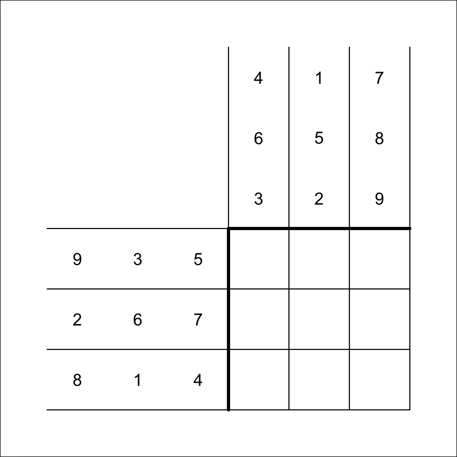

What is $c_{2,1}$?

To find $c_{2,1}$, you use row 2 from matrix $A$ and column 1 from matrix $B$.

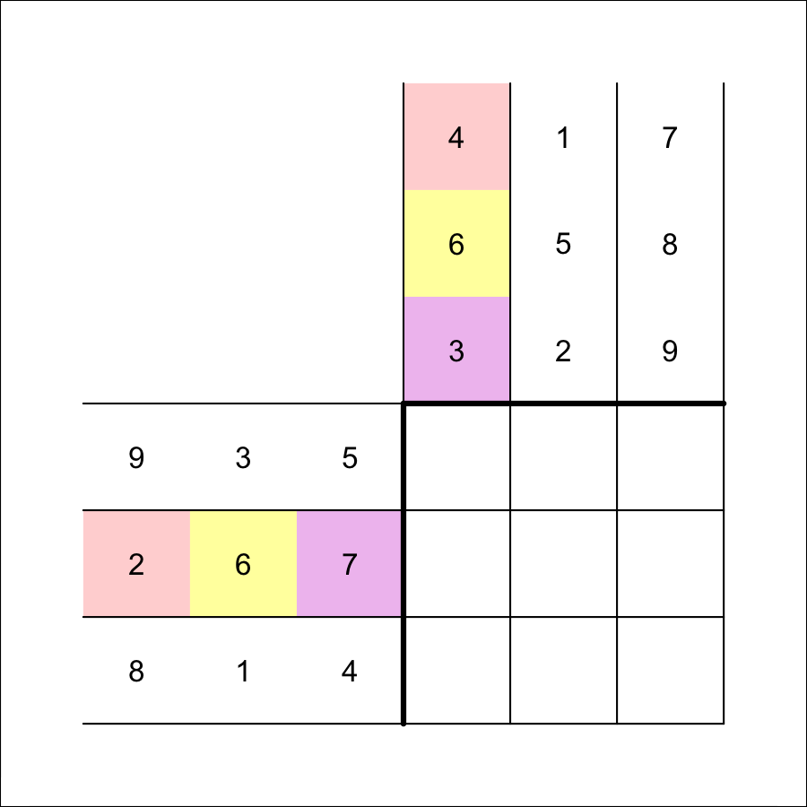

You multiply corresponding elements and sum those products.

$$c_{2,1}~=~( 2 \cdot 4 )+( 6 \cdot 6
)+( 7 \cdot 3 )$$

$$c_{2,1}~=~8+36+21$$

$$c_{2,1}~=~65$$

If you repeat this process for all 9 elements in $C$, you get:

$$\begin{bmatrix}
9 & 3 & 5\\
2 & 6 & 7\\
8 & 1 & 4
\end{bmatrix} \cdot \begin{bmatrix}
4 & 1 & 7\\
6 & 5 & 8\\
3 & 2 & 9
\end{bmatrix} ~=~ \begin{bmatrix}
69 & 34 & 132\\
65 & 46 & 125\\
50 & 21 & 100
\end{bmatrix}$$

Let matrices $A$ and $B$ be defined below.

$$A = \begin{bmatrix}
4 & 2 & 9\\
7 & 5 & 3\\
8 & 6 & 1
\end{bmatrix}$$
$$B = \begin{bmatrix}
7 & 4 & 5\\
3 & 1 & 6\\
9 & 8 & 2
\end{bmatrix}$$

A third matrix, $C$, is equal to the [product](https://en.wikipedia.org/wiki/Matrix_multiplication) $AB$. A student set up a diagram to help find the product:

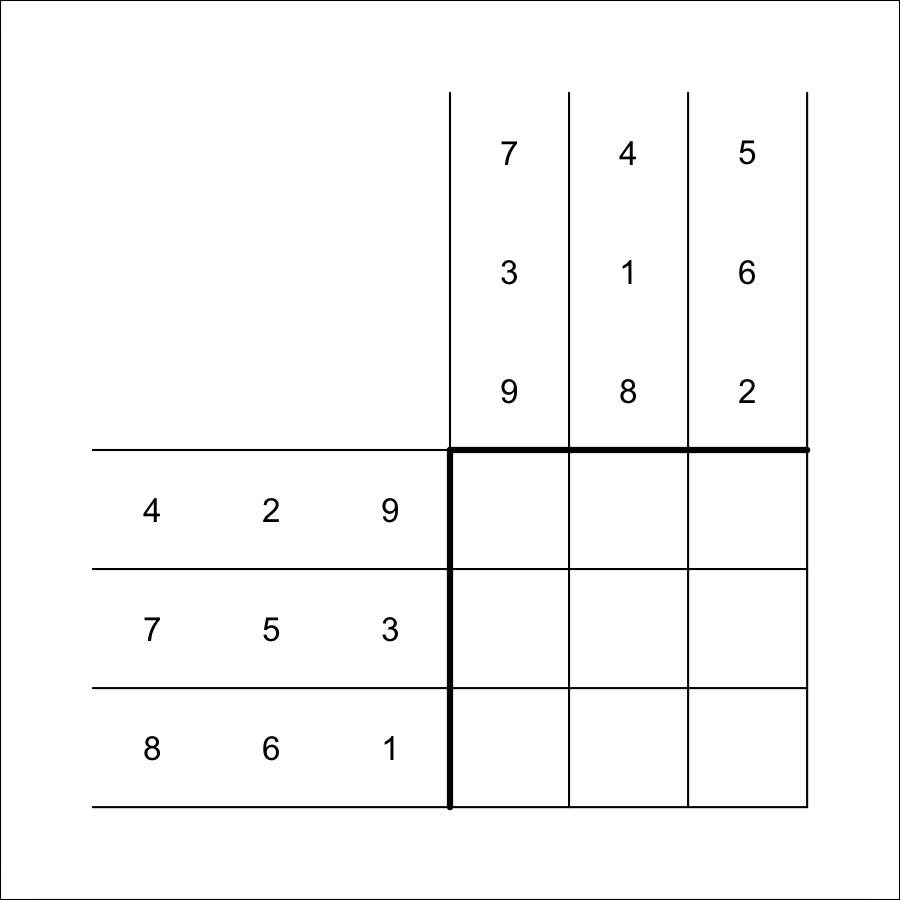

What is $c_{1,3}$?

To find $c_{1,3}$, you use row 1 from matrix $A$ and column 3 from matrix $B$.

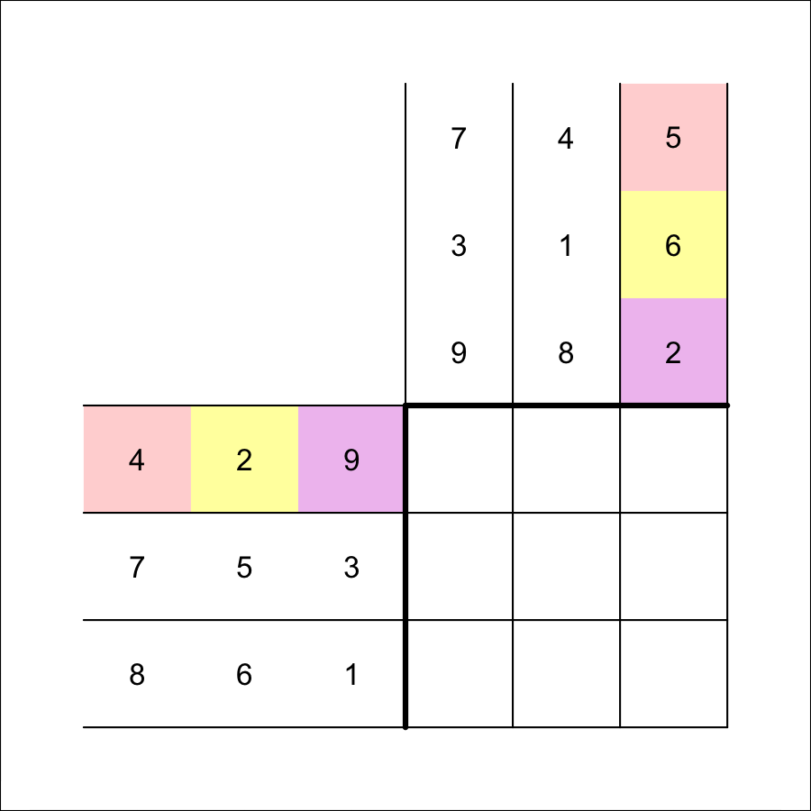

You multiply corresponding elements and sum those products.

$$c_{1,3}~=~( 4 \cdot 5 )+( 2 \cdot 6
)+( 9 \cdot 2 )$$

$$c_{1,3}~=~20+12+18$$

$$c_{1,3}~=~50$$

If you repeat this process for all 9 elements in $C$, you get:

$$\begin{bmatrix}
4 & 2 & 9\\
7 & 5 & 3\\
8 & 6 & 1
\end{bmatrix} \cdot \begin{bmatrix}
7 & 4 & 5\\
3 & 1 & 6\\
9 & 8 & 2
\end{bmatrix} ~=~ \begin{bmatrix}
115 & 90 & 50\\
91 & 57 & 71\\
83 & 46 & 78
\end{bmatrix}$$

Let matrices $A$ and $B$ be defined below.

$$A = \begin{bmatrix}
8 & 9 & 5\\
7 & 1 & 6\\
3 & 2 & 4
\end{bmatrix}$$
$$B = \begin{bmatrix}
3 & 9 & 6\\
8 & 2 & 7\\
1 & 5 & 4
\end{bmatrix}$$

A third matrix, $C$, is equal to the [product](https://en.wikipedia.org/wiki/Matrix_multiplication) $AB$. A student set up a diagram to help find the product:

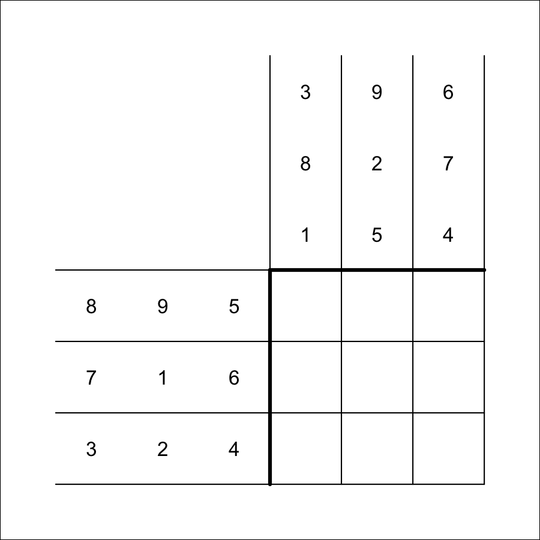

What is $c_{3,2}$?

To find $c_{3,2}$, you use row 3 from matrix $A$ and column 2 from matrix $B$.

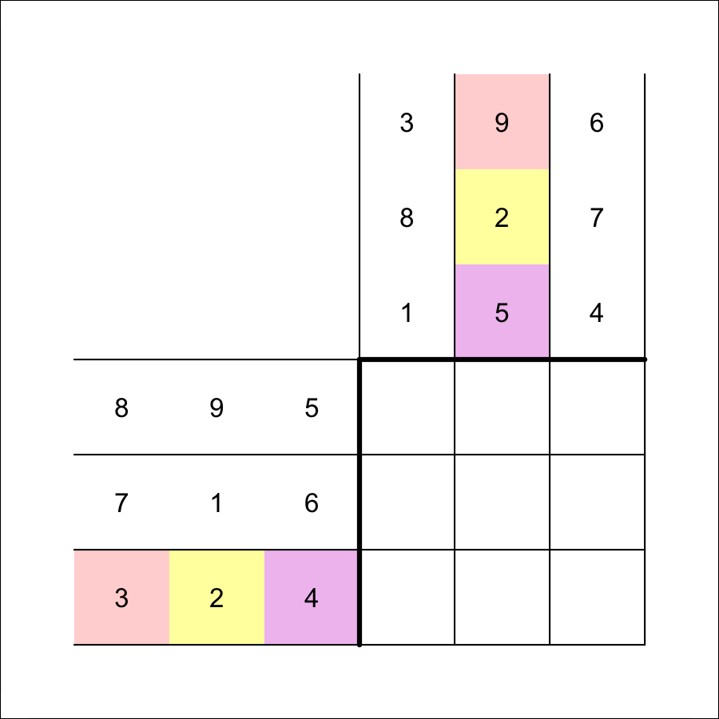

You multiply corresponding elements and sum those products.

$$c_{3,2}~=~( 3 \cdot 9 )+( 2 \cdot 2
)+( 4 \cdot 5 )$$

$$c_{3,2}~=~27+4+20$$

$$c_{3,2}~=~51$$

If you repeat this process for all 9 elements in $C$, you get:

$$\begin{bmatrix}
8 & 9 & 5\\
7 & 1 & 6\\
3 & 2 & 4
\end{bmatrix} \cdot \begin{bmatrix}
3 & 9 & 6\\
8 & 2 & 7\\
1 & 5 & 4
\end{bmatrix} ~=~ \begin{bmatrix}
101 & 115 & 131\\
35 & 95 & 73\\
29 & 51 & 48
\end{bmatrix}$$

Let matrices $A$ and $B$ be defined below.

$$A = \begin{bmatrix}
1 & 4 & 3\\
7 & 2 & 6\\
5 & 9 & 8
\end{bmatrix}$$
$$B = \begin{bmatrix}
5 & 1 & 2\\
6 & 7 & 8\\
9 & 4 & 3
\end{bmatrix}$$

A third matrix, $C$, is equal to the [product](https://en.wikipedia.org/wiki/Matrix_multiplication) $AB$. A student set up a diagram to help find the product:

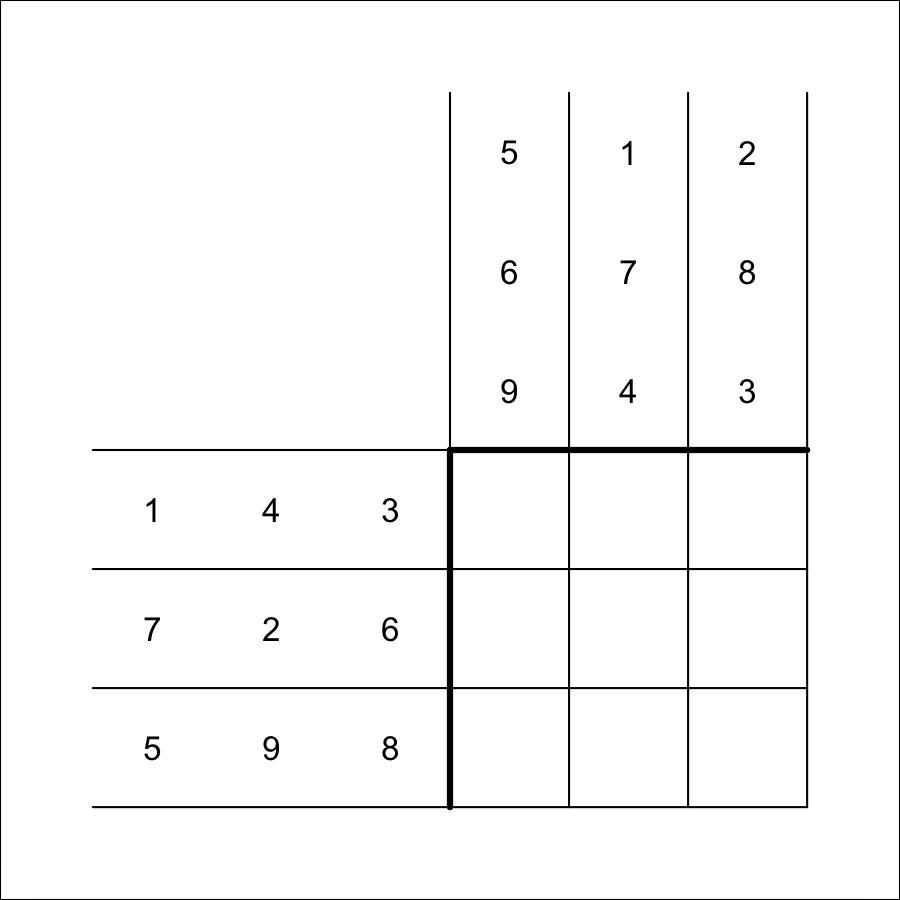

What is $c_{2,1}$?

To find $c_{2,1}$, you use row 2 from matrix $A$ and column 1 from matrix $B$.

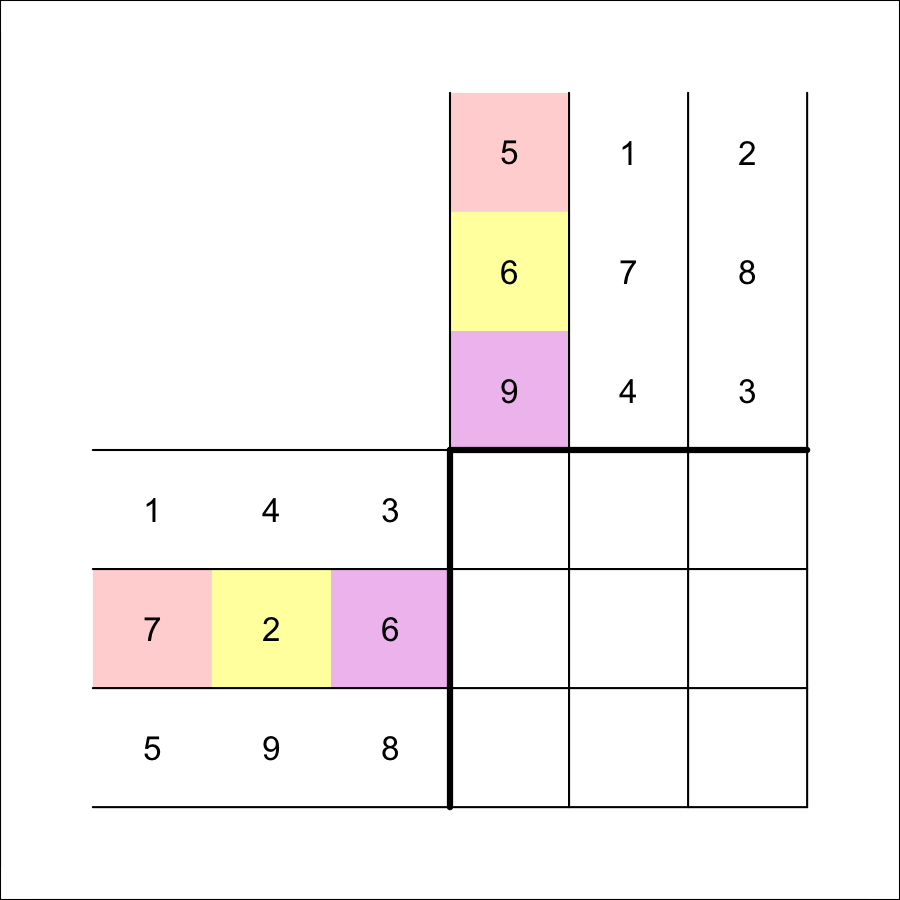

You multiply corresponding elements and sum those products.

$$c_{2,1}~=~( 7 \cdot 5 )+( 2 \cdot 6
)+( 6 \cdot 9 )$$

$$c_{2,1}~=~35+12+54$$

$$c_{2,1}~=~101$$

If you repeat this process for all 9 elements in $C$, you get:

$$\begin{bmatrix}
1 & 4 & 3\\
7 & 2 & 6\\
5 & 9 & 8
\end{bmatrix} \cdot \begin{bmatrix}
5 & 1 & 2\\
6 & 7 & 8\\
9 & 4 & 3
\end{bmatrix} ~=~ \begin{bmatrix}
56 & 41 & 43\\
101 & 45 & 48\\
151 & 100 & 106
\end{bmatrix}$$

Let matrices $A$ and $B$ be defined below.

$$A = \begin{bmatrix}
9 & 6 & 4\\
3 & 7 & 5\\
8 & 2 & 1
\end{bmatrix}$$
$$B = \begin{bmatrix}
5 & 2 & 9\\
1 & 3 & 7\\
4 & 6 & 8
\end{bmatrix}$$

A third matrix, $C$, is equal to the [product](https://en.wikipedia.org/wiki/Matrix_multiplication) $AB$. A student set up a diagram to help find the product:

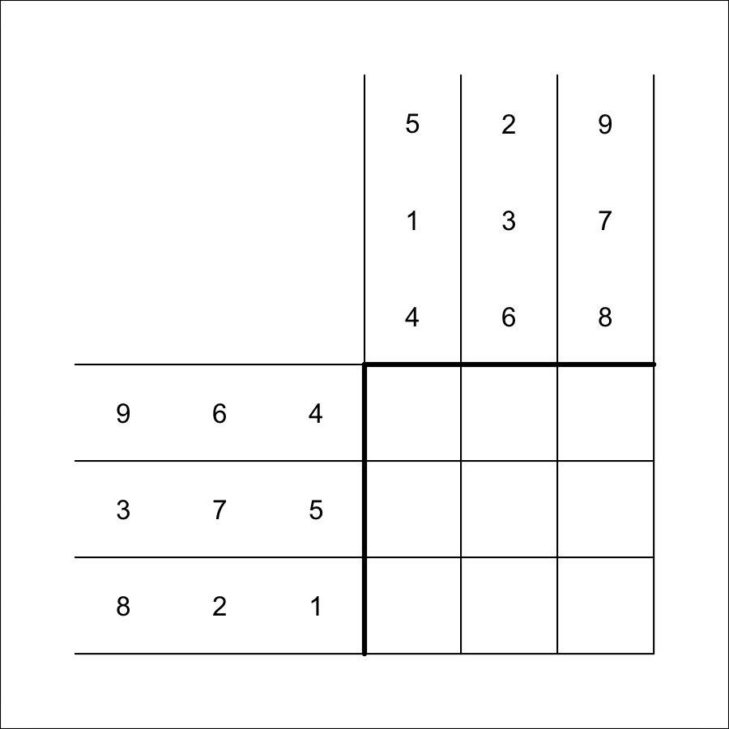

What is $c_{1,3}$?

To find $c_{1,3}$, you use row 1 from matrix $A$ and column 3 from matrix $B$.

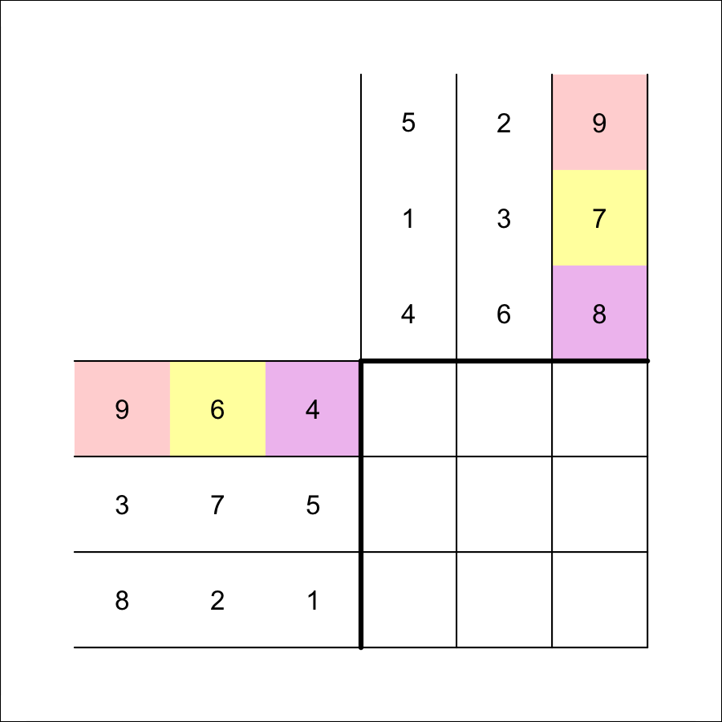

You multiply corresponding elements and sum those products.

$$c_{1,3}~=~( 9 \cdot 9 )+( 6 \cdot 7
)+( 4 \cdot 8 )$$

$$c_{1,3}~=~81+42+32$$

$$c_{1,3}~=~155$$

If you repeat this process for all 9 elements in $C$, you get:

$$\begin{bmatrix}
9 & 6 & 4\\
3 & 7 & 5\\
8 & 2 & 1
\end{bmatrix} \cdot \begin{bmatrix}
5 & 2 & 9\\
1 & 3 & 7\\
4 & 6 & 8
\end{bmatrix} ~=~ \begin{bmatrix}
67 & 60 & 155\\
42 & 57 & 116\\
46 & 28 & 94
\end{bmatrix}$$

Let matrices $A$ and $B$ be defined below.

$$A = \begin{bmatrix}
8 & 1 & 6\\
2 & 3 & 4\\
5 & 9 & 7
\end{bmatrix}$$
$$B = \begin{bmatrix}
9 & 7 & 3\\
5 & 8 & 6\\
2 & 4 & 1
\end{bmatrix}$$

A third matrix, $C$, is equal to the [product](https://en.wikipedia.org/wiki/Matrix_multiplication) $AB$. A student set up a diagram to help find the product:

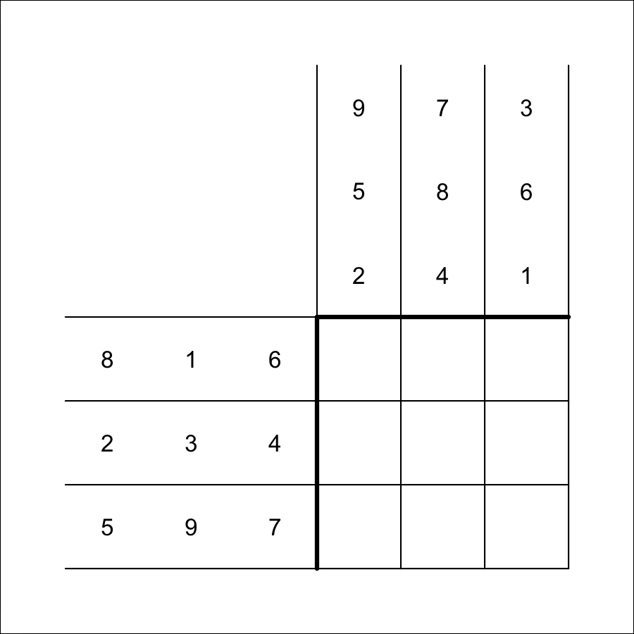

What is $c_{1,2}$?

To find $c_{1,2}$, you use row 1 from matrix $A$ and column 2 from matrix $B$.

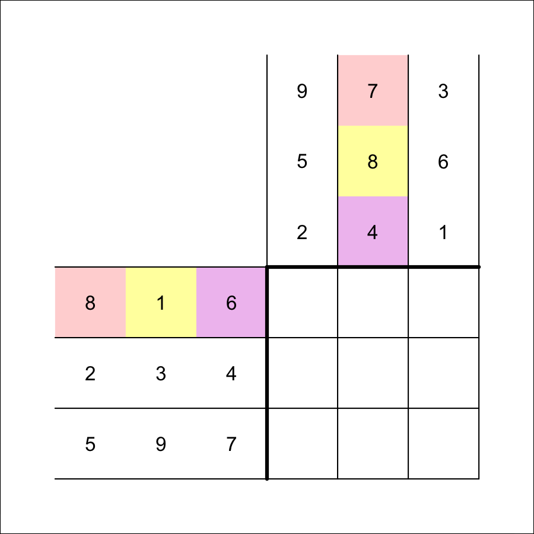

You multiply corresponding elements and sum those products.

$$c_{1,2}~=~( 8 \cdot 7 )+( 1 \cdot 8
)+( 6 \cdot 4 )$$

$$c_{1,2}~=~56+8+24$$

$$c_{1,2}~=~88$$

If you repeat this process for all 9 elements in $C$, you get:

$$\begin{bmatrix}
8 & 1 & 6\\
2 & 3 & 4\\
5 & 9 & 7
\end{bmatrix} \cdot \begin{bmatrix}
9 & 7 & 3\\
5 & 8 & 6\\
2 & 4 & 1
\end{bmatrix} ~=~ \begin{bmatrix}
89 & 88 & 36\\
41 & 54 & 28\\
104 & 135 & 76
\end{bmatrix}$$

Let matrices $A$ and $B$ be defined below.

$$A = \begin{bmatrix}
4 & 2 & 9\\
6 & 5 & 3\\
7 & 8 & 1
\end{bmatrix}$$
$$B = \begin{bmatrix}
9 & 1 & 6\\
8 & 4 & 2\\
3 & 7 & 5
\end{bmatrix}$$

A third matrix, $C$, is equal to the [product](https://en.wikipedia.org/wiki/Matrix_multiplication) $AB$. A student set up a diagram to help find the product:

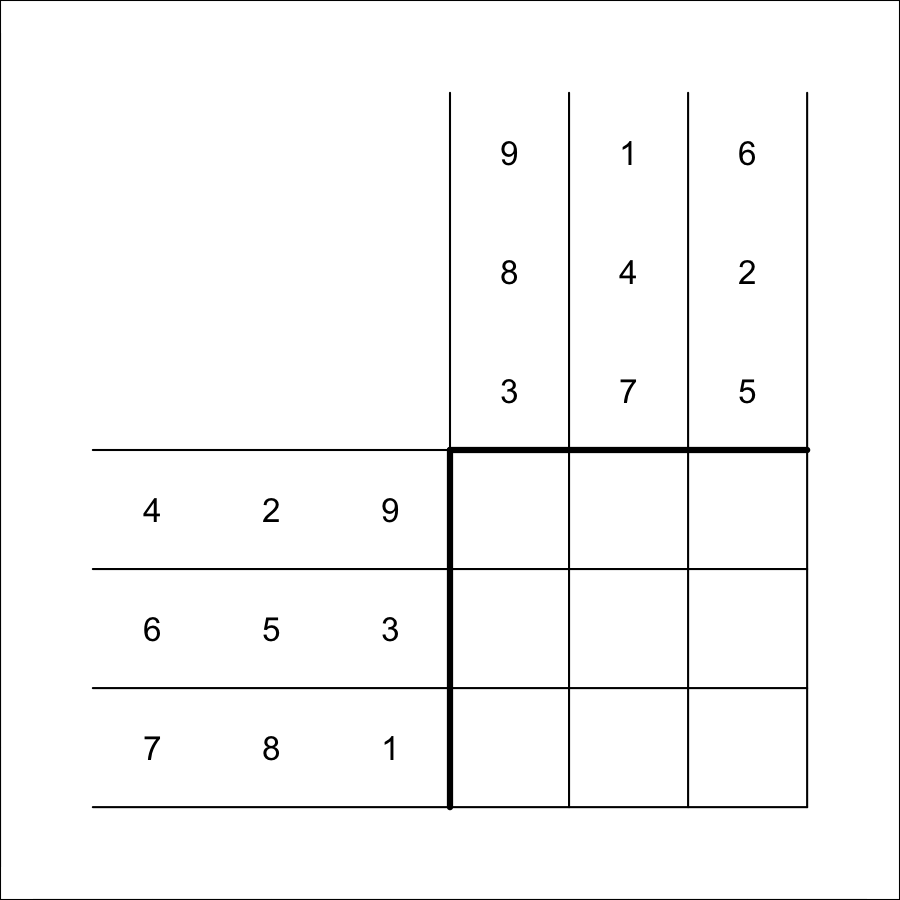

What is $c_{1,3}$?

To find $c_{1,3}$, you use row 1 from matrix $A$ and column 3 from matrix $B$.

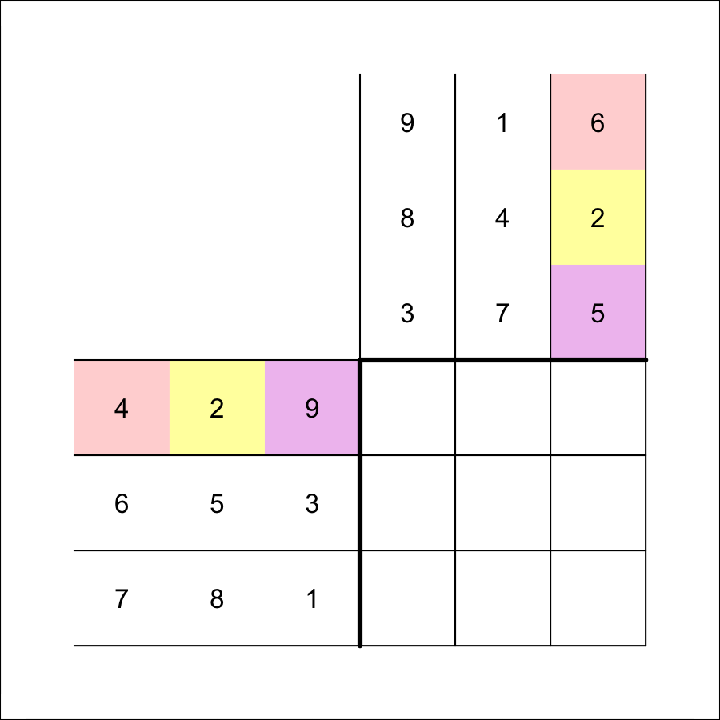

You multiply corresponding elements and sum those products.

$$c_{1,3}~=~( 4 \cdot 6 )+( 2 \cdot 2
)+( 9 \cdot 5 )$$

$$c_{1,3}~=~24+4+45$$

$$c_{1,3}~=~73$$

If you repeat this process for all 9 elements in $C$, you get:

$$\begin{bmatrix}
4 & 2 & 9\\
6 & 5 & 3\\
7 & 8 & 1
\end{bmatrix} \cdot \begin{bmatrix}
9 & 1 & 6\\
8 & 4 & 2\\
3 & 7 & 5
\end{bmatrix} ~=~ \begin{bmatrix}
79 & 75 & 73\\
103 & 47 & 61\\
130 & 46 & 63
\end{bmatrix}$$

Let matrices $A$ and $B$ be defined below.

$$A = \begin{bmatrix}
8 & 1 & 2\\
5 & 6 & 7\\
4 & 9 & 3
\end{bmatrix}$$
$$B = \begin{bmatrix}
9 & 3 & 1\\
5 & 4 & 8\\
2 & 7 & 6
\end{bmatrix}$$

A third matrix, $C$, is equal to the [product](https://en.wikipedia.org/wiki/Matrix_multiplication) $AB$. A student set up a diagram to help find the product:

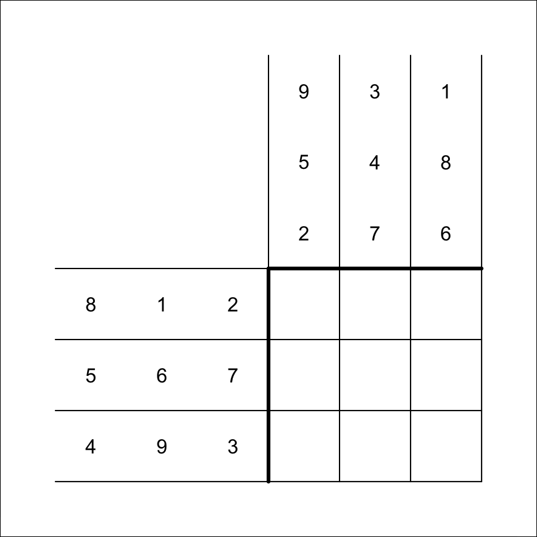

What is $c_{3,2}$?

To find $c_{3,2}$, you use row 3 from matrix $A$ and column 2 from matrix $B$.

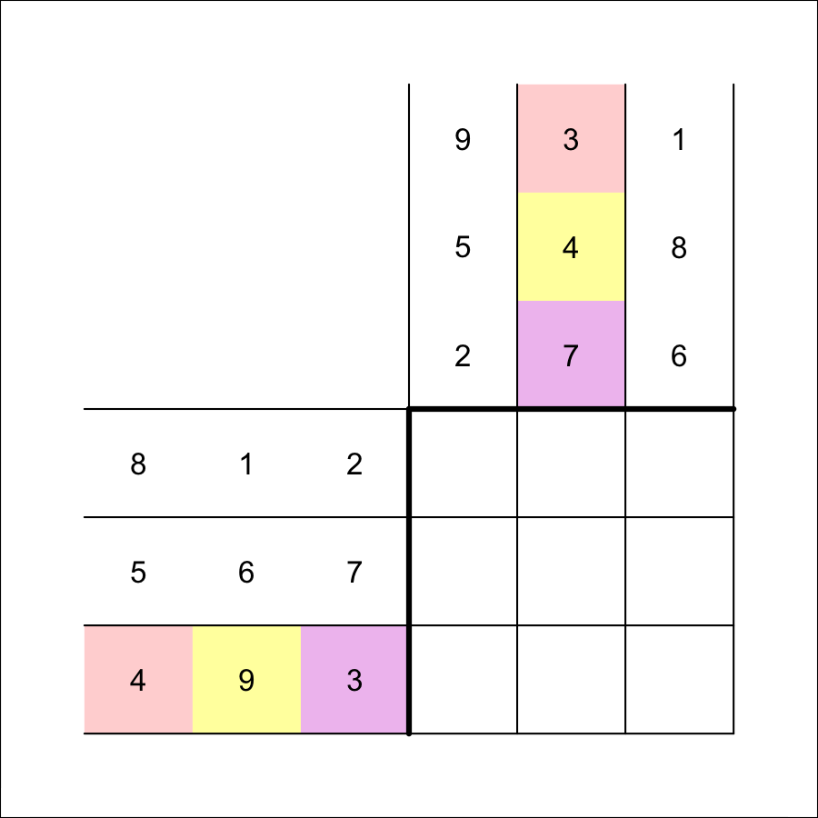

You multiply corresponding elements and sum those products.

$$c_{3,2}~=~( 4 \cdot 3 )+( 9 \cdot 4
)+( 3 \cdot 7 )$$

$$c_{3,2}~=~12+36+21$$

$$c_{3,2}~=~69$$

If you repeat this process for all 9 elements in $C$, you get:

$$\begin{bmatrix}
8 & 1 & 2\\
5 & 6 & 7\\
4 & 9 & 3
\end{bmatrix} \cdot \begin{bmatrix}
9 & 3 & 1\\
5 & 4 & 8\\
2 & 7 & 6
\end{bmatrix} ~=~ \begin{bmatrix}
81 & 42 & 28\\
89 & 88 & 95\\
87 & 69 & 94
\end{bmatrix}$$

Let matrices $A$ and $B$ be defined below.

$$A = \begin{bmatrix}
7 & 4 & 8\\
9 & 5 & 3\\
2 & 1 & 6
\end{bmatrix}$$
$$B = \begin{bmatrix}
7 & 6 & 4\\
9 & 1 & 3\\
5 & 8 & 2
\end{bmatrix}$$

A third matrix, $C$, is equal to the [product](https://en.wikipedia.org/wiki/Matrix_multiplication) $AB$. A student set up a diagram to help find the product:

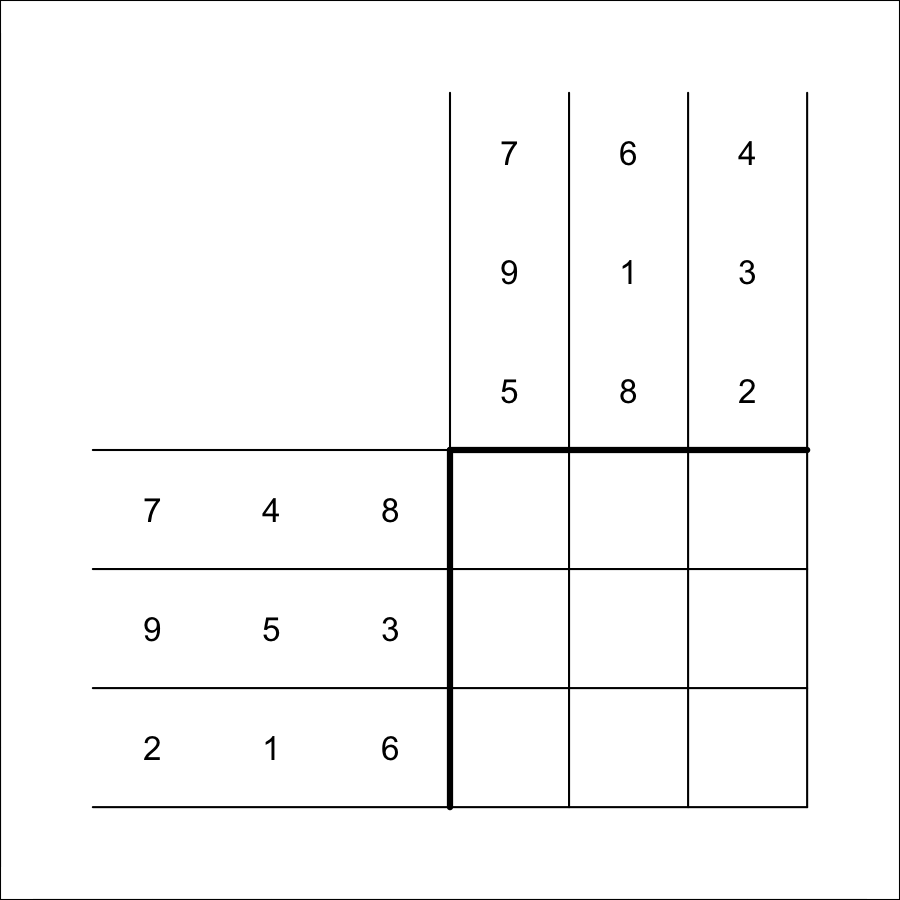

What is $c_{1,2}$?

To find $c_{1,2}$, you use row 1 from matrix $A$ and column 2 from matrix $B$.

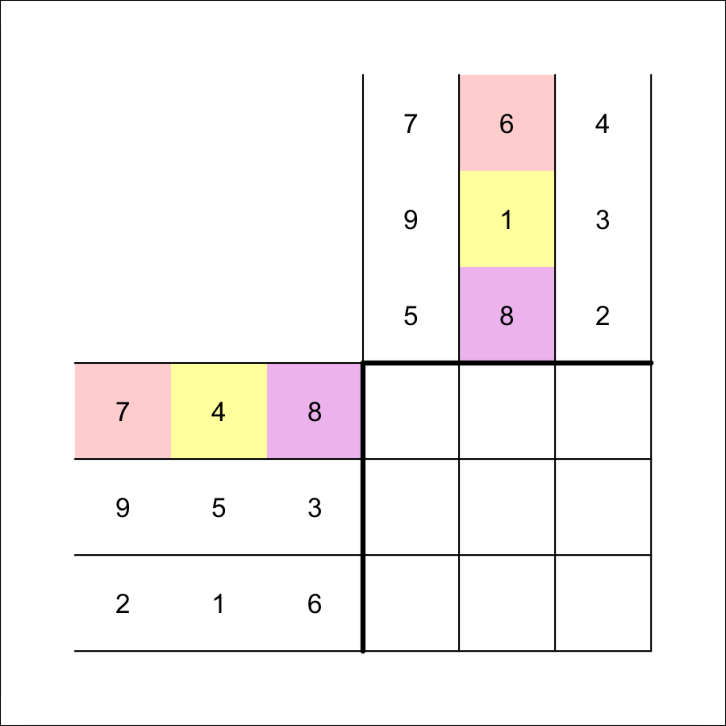

You multiply corresponding elements and sum those products.

$$c_{1,2}~=~( 7 \cdot 6 )+( 4 \cdot 1
)+( 8 \cdot 8 )$$

$$c_{1,2}~=~42+4+64$$

$$c_{1,2}~=~110$$

If you repeat this process for all 9 elements in $C$, you get:

$$\begin{bmatrix}
7 & 4 & 8\\
9 & 5 & 3\\
2 & 1 & 6
\end{bmatrix} \cdot \begin{bmatrix}
7 & 6 & 4\\
9 & 1 & 3\\
5 & 8 & 2
\end{bmatrix} ~=~ \begin{bmatrix}
125 & 110 & 56\\
123 & 83 & 57\\
53 & 61 & 23
\end{bmatrix}$$

Let matrices $A$ and $B$ be defined below.

$$A = \begin{bmatrix}
4 & 6 & 2\\
1 & 9 & 8\\
3 & 7 & 5
\end{bmatrix}$$
$$B = \begin{bmatrix}
3 & 6 & 9\\
2 & 8 & 5\\
4 & 7 & 1
\end{bmatrix}$$

A third matrix, $C$, is equal to the [product](https://en.wikipedia.org/wiki/Matrix_multiplication) $AB$. A student set up a diagram to help find the product:

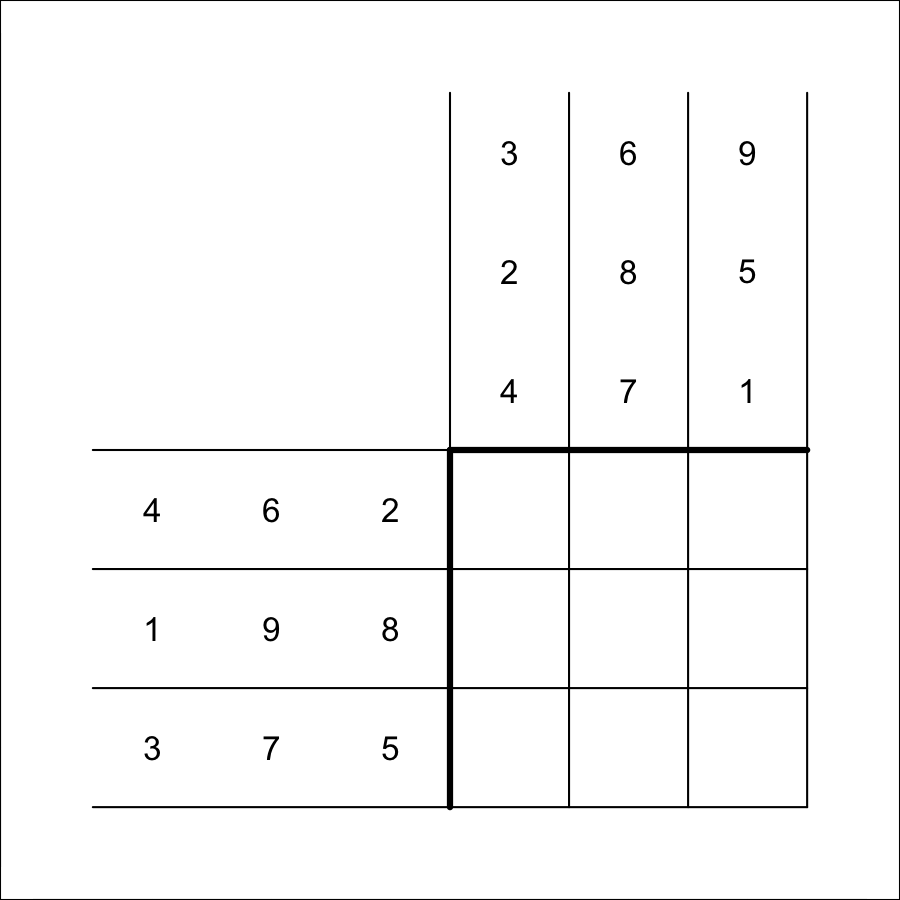

What is $c_{1,2}$?

To find $c_{1,2}$, you use row 1 from matrix $A$ and column 2 from matrix $B$.

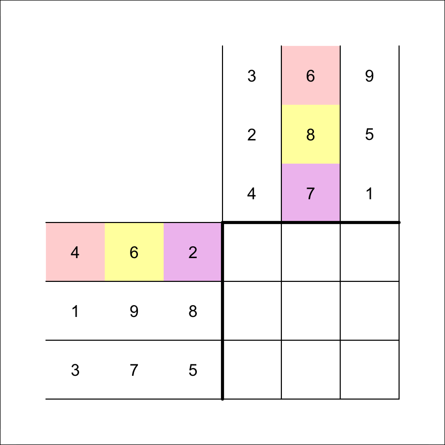

You multiply corresponding elements and sum those products.

$$c_{1,2}~=~( 4 \cdot 6 )+( 6 \cdot 8
)+( 2 \cdot 7 )$$

$$c_{1,2}~=~24+48+14$$

$$c_{1,2}~=~86$$

If you repeat this process for all 9 elements in $C$, you get:

$$\begin{bmatrix}
4 & 6 & 2\\
1 & 9 & 8\\
3 & 7 & 5
\end{bmatrix} \cdot \begin{bmatrix}
3 & 6 & 9\\
2 & 8 & 5\\
4 & 7 & 1
\end{bmatrix} ~=~ \begin{bmatrix}
32 & 86 & 68\\
53 & 134 & 62\\
43 & 109 & 67
\end{bmatrix}$$

Let matrices $A$ and $B$ be defined below.

$$A = \begin{bmatrix}
7 & 5 & 3\\
1 & 2 & 8\\
9 & 4 & 6
\end{bmatrix}$$
$$B = \begin{bmatrix}
3 & 1 & 2\\
9 & 5 & 8\\
6 & 4 & 7
\end{bmatrix}$$

A third matrix, $C$, is equal to the [product](https://en.wikipedia.org/wiki/Matrix_multiplication) $AB$. A student set up a diagram to help find the product:

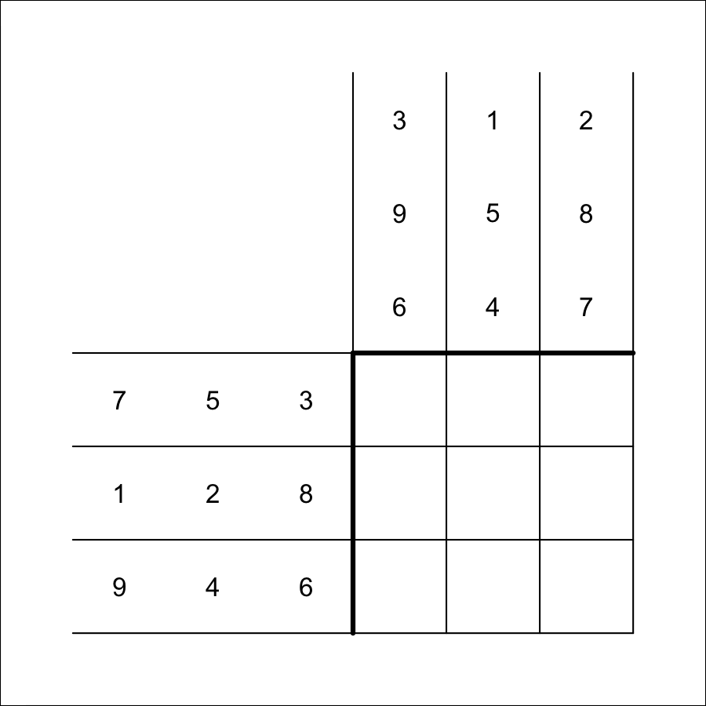

What is $c_{3,2}$?

To find $c_{3,2}$, you use row 3 from matrix $A$ and column 2 from matrix $B$.

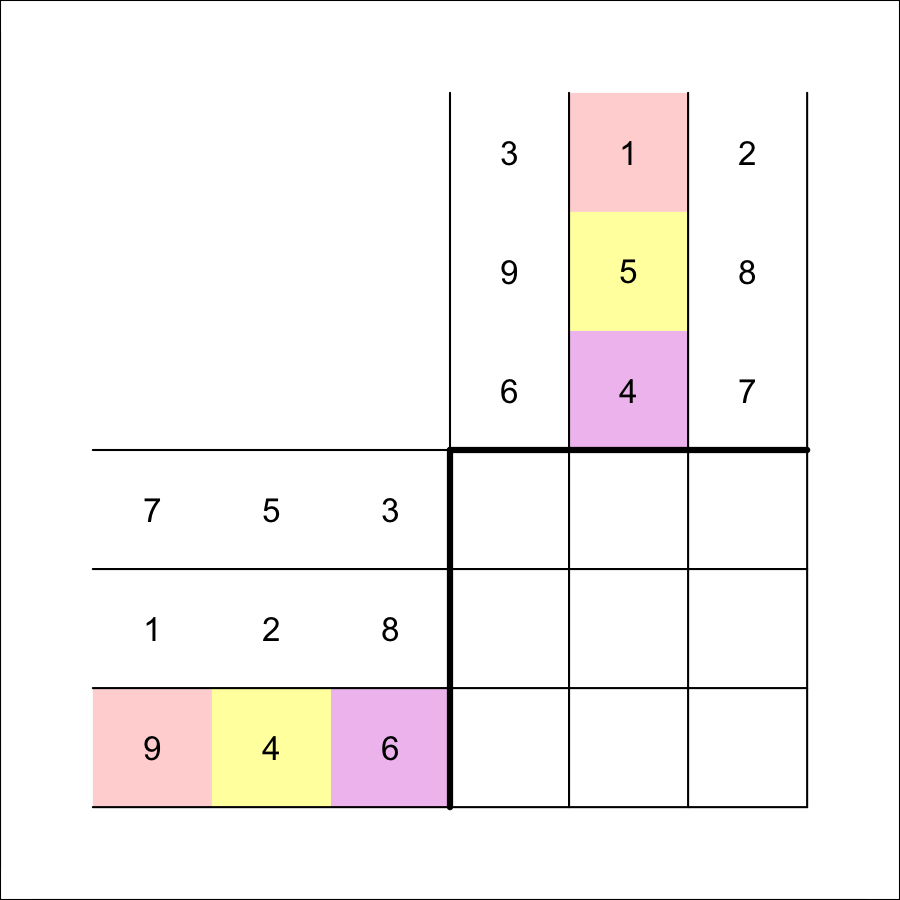

You multiply corresponding elements and sum those products.

$$c_{3,2}~=~( 9 \cdot 1 )+( 4 \cdot 5
)+( 6 \cdot 4 )$$

$$c_{3,2}~=~9+20+24$$

$$c_{3,2}~=~53$$

If you repeat this process for all 9 elements in $C$, you get:

$$\begin{bmatrix}
7 & 5 & 3\\
1 & 2 & 8\\
9 & 4 & 6
\end{bmatrix} \cdot \begin{bmatrix}
3 & 1 & 2\\
9 & 5 & 8\\
6 & 4 & 7
\end{bmatrix} ~=~ \begin{bmatrix}
84 & 44 & 75\\
69 & 43 & 74\\
99 & 53 & 92
\end{bmatrix}$$

Let matrices $A$ and $B$ be defined below.

$$A = \begin{bmatrix}
8 & 4 & 1\\
2 & 7 & 9\\
6 & 3 & 5
\end{bmatrix}$$
$$B = \begin{bmatrix}
6 & 8 & 3\\
5 & 4 & 9\\
7 & 1 & 2
\end{bmatrix}$$

A third matrix, $C$, is equal to the [product](https://en.wikipedia.org/wiki/Matrix_multiplication) $AB$. A student set up a diagram to help find the product:

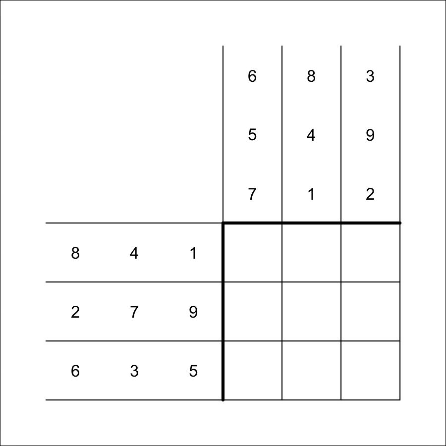

What is $c_{1,2}$?

To find $c_{1,2}$, you use row 1 from matrix $A$ and column 2 from matrix $B$.

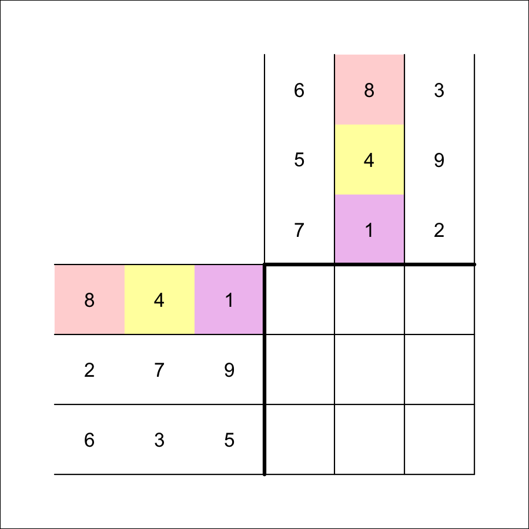

You multiply corresponding elements and sum those products.

$$c_{1,2}~=~( 8 \cdot 8 )+( 4 \cdot 4
)+( 1 \cdot 1 )$$

$$c_{1,2}~=~64+16+1$$

$$c_{1,2}~=~81$$

If you repeat this process for all 9 elements in $C$, you get:

$$\begin{bmatrix}
8 & 4 & 1\\
2 & 7 & 9\\
6 & 3 & 5
\end{bmatrix} \cdot \begin{bmatrix}
6 & 8 & 3\\
5 & 4 & 9\\
7 & 1 & 2
\end{bmatrix} ~=~ \begin{bmatrix}
75 & 81 & 62\\
110 & 53 & 87\\
86 & 65 & 55
\end{bmatrix}$$